# How to select a satisfying board game? - Part 1

James Diu

2020-07-11

–>

Being a board game enthusiast, I always introduce board games to my friends. Some of them might be another enthusiast, while some might have an idea that the board game is equivalent to chess. Most of the time I use my instinct and my understanding of the taste of my friends to decide which game would provide the greatest fun for us. However, it can be very biased due to my personal preference. On the other hand, I love to collect *different* board games. I hope my collection can be diverse enough to serve all kinds of my friends’ backgrounds and preferences. So how should I choose a game to meet general preference? And which game should I select, such that it will enrich my collection and make sure it could be fun? (It is quite upset when you find out a new game is boring…) Perhaps learning more about the general preference statistically is not a bad idea.

## Data description

Regarding the data of board games, [BoardGameGeek(BGG)](https://boardgamegeek.com/) is undoubtedly the biggest source. However, I am not going to pull the data directly. Instead, I will use the data from an interesting [post](https://dvatvani.github.io/BGG-Analysis-Part-1.html) about the trend and rating bias on BGG in 2018, which also come from BGG. Although it is not up-to-date data, I think it can still give us some insights and suggestions.

```r
games_Jan2018 <- read_csv("data/games_Jan2018.csv")
df <- games_Jan2018
```

In this dataset, we have total 95,777 board games, including the base games(80,105) and its expansion(15,672). The information can also be separated into 2 groups: games features and responses on BGG. Since some information is useless or duplicated, below are the useful columns:

Features: `type`, `yearpublished`, `minplayers`, `maxplayers`, `minplaytime`, `maxplaytime`, `minage`, `types`, `categories`, `mechanics`, `desginers`

Responses: `users_rated`, `bayes_average_rating`, `total_owners`, `total_trader`, `total_wanters`, `total_wisher`, `total_comments`, `average_weight`

One of the most important data is `bayes_average_rating`, which is only available for the games with at least 30 users rating. It is used instead of the average player rating in order to exclude those games which few ratings, so that to prevent the bias from small sample size. After filtering out those data without 30 users rating, we still have 15,026 games and 4,714 expansion and we will place our focus on them.

```r
df %>% filter(users_rated>=30) %>% group_by(type) %>% summarise(n=n())
```

```
## # A tibble: 2 x 2
##    type     n
##   <dbl> <int>
## 1     0 15026
## 2     1  4714
```

```r
df <- df %>% filter(users_rated>=30)
```

Now we have a rough idea about what cards are on our hand. Let’s find out so further information from them. In the beginning, we will start with the numerical data.

### Correlation

Below is the correlation table among different numerical features. We can see the BGG rating has a positive correlation with the average weight and minimum age, and also slightly positively correlated to the year of publish. Meanwhile, we can also notice that the rating is somehow independent of the number of players and the duration of playing time, but both features show some dependence on both features. Therefore we will go through all these features one by one.

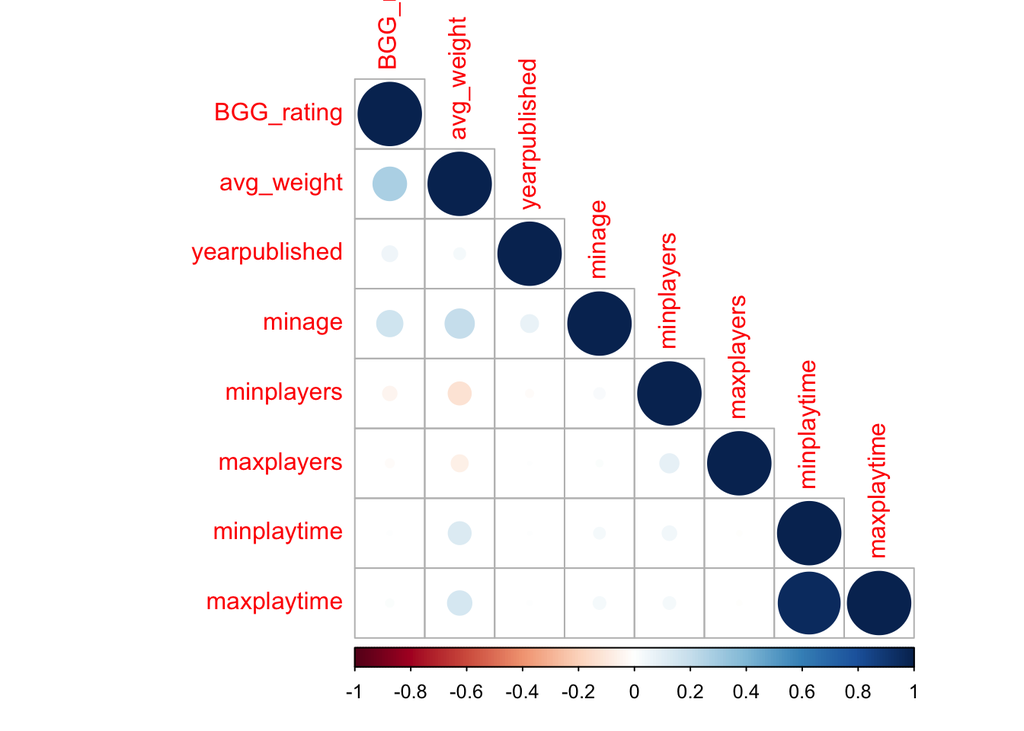

### Weight

It obvious to notice that the weight of games has positive skewness, with the mode at 2. Meanwhile, we should be reminded that this is a score provided by the users, which means this is a relative value to other games. Due to the same reason, perhaps we should consider using other fixed features to replace this subjective feature.

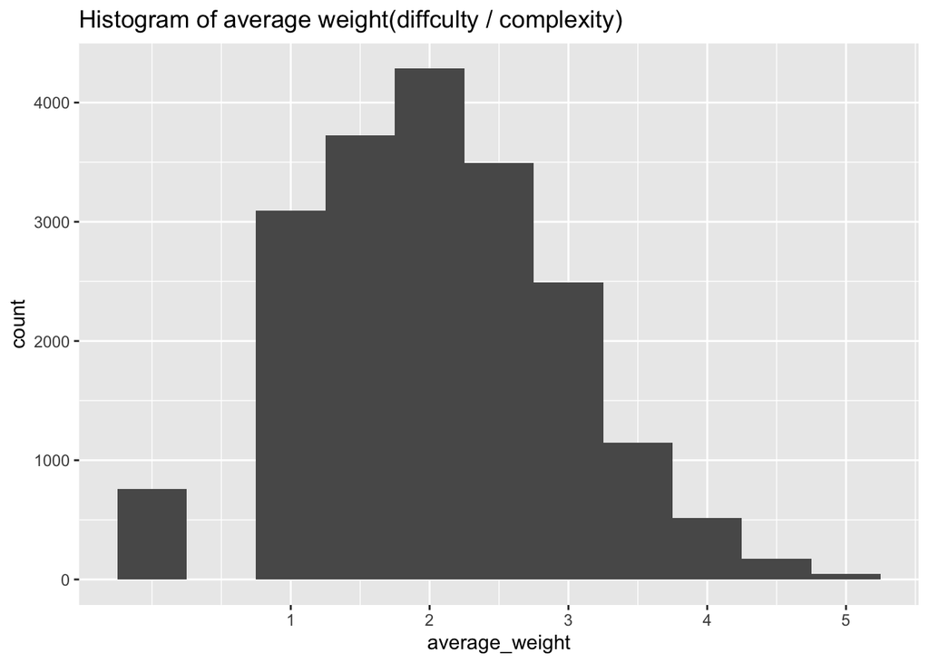

### Year of publish

Since some of the games on our list do not have a clear publish date. Therefore we will start with the games published on or after 1985, which have already cover 90% of the games. For the rest of the data, I will set them to NA as irrelevant due to the small sample size.

```r
sort(df$yearpublished)[round(nrow(df)/10)]
```

```
## [1] 1985
```

From the below plot, the average BGG rating raises slightly over the years. However, it is hard to conclude whether the games published are getting better or the baseline of users rating is going upwards. One interesting thing to notice is the ratings of games are spreading further to the higher rating, and so does the best rating. This would be the result of the increase of games published.

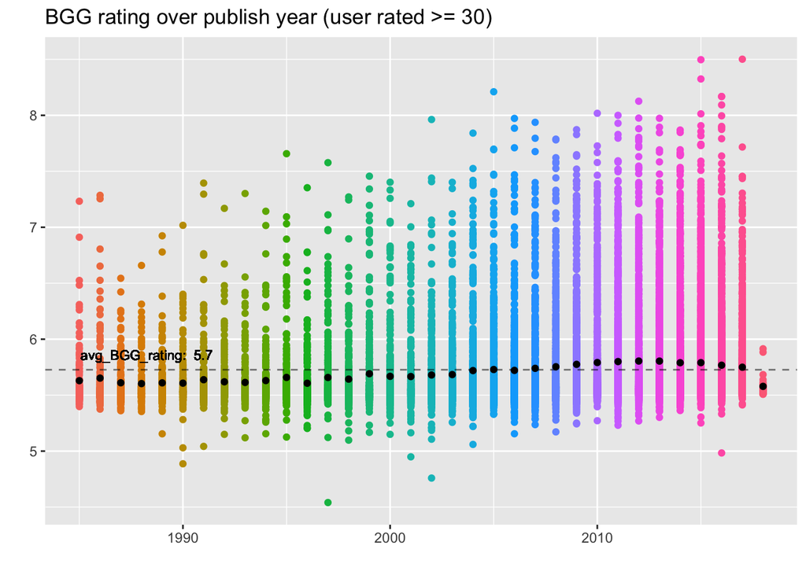

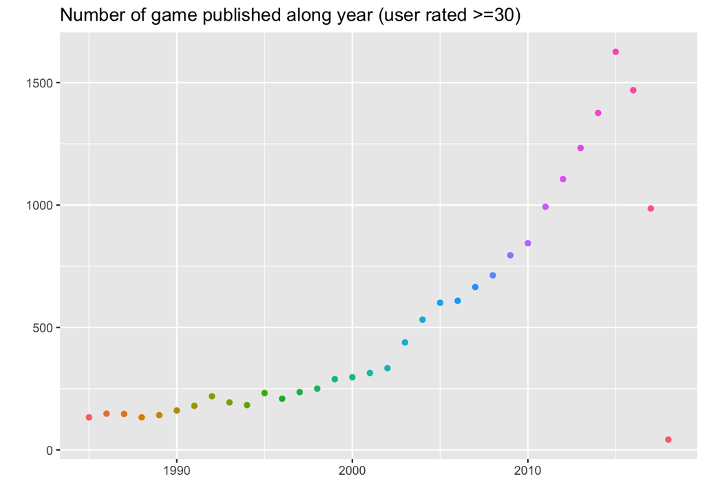

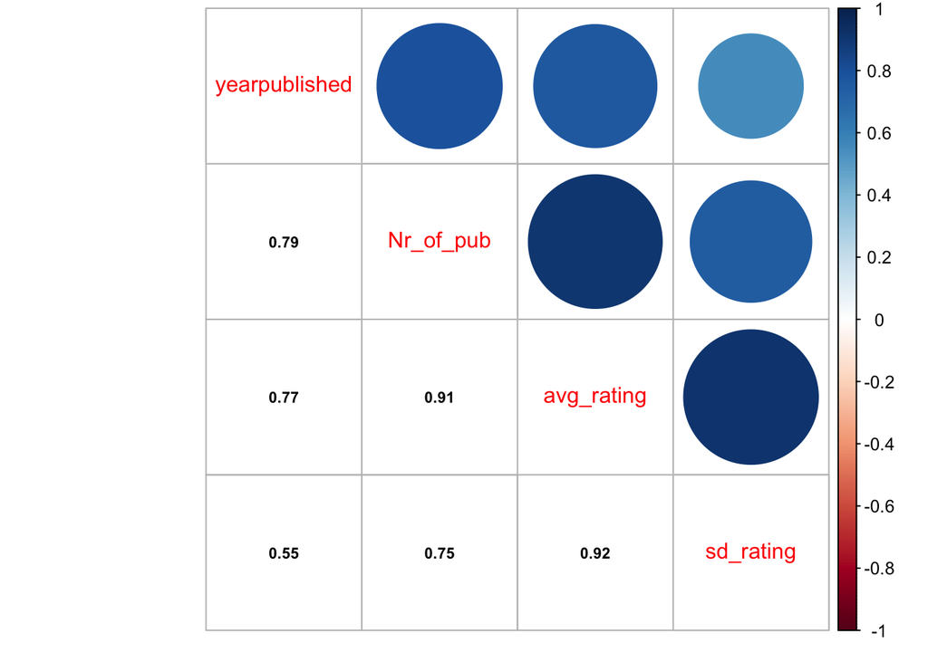

### Minimum age

We can know that the minimum age is positively correlated to weight and rating from the correlation chart before. It is reasonable because most of the BGG users are not children and I have sure they are not that interested in those games for children. This fact also implies the evaluation of children’s games may be invalid since the focus group is different. Besides, the minimum age mainly falls into 5 ages: 8,10,12-14 and the distribution is very inbalance. In general, the purpose of minimum age is an index for the complexity and content However, the judgment depends highly on the publisher (noted that games specially for 18+ are rare), therefore I would also prefer to transfer minimum age into 5 groups: <6, 6-8, 9-11, 12-14, 15+

```r
df <- df %>% mutate(age_group = ifelse(minage>14, "15+",
                                        ifelse(minage>11, "12-14",
                                               ifelse(minage>8, "9-11",
                                                      ifelse(minage>5, "6-8","<6")))),
                     age_group = factor(age_group, levels = c("<6", "6-8", "9-11","12-14","15+")))
```

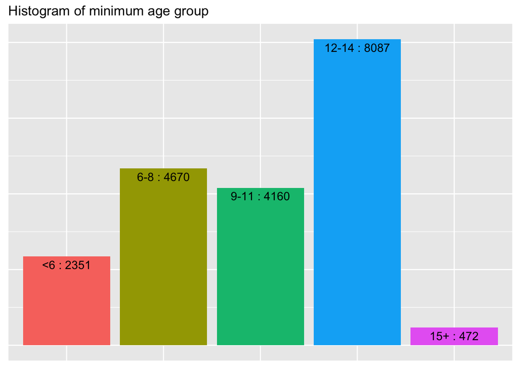

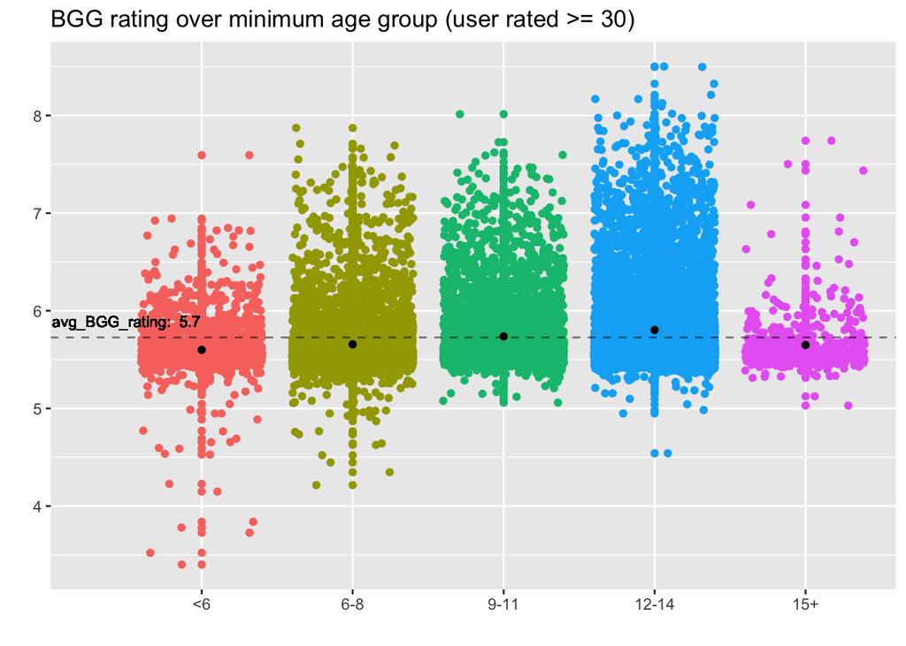

### Number of players

Most of the games can afford 2-4 players without any surprise.

[output not shown]

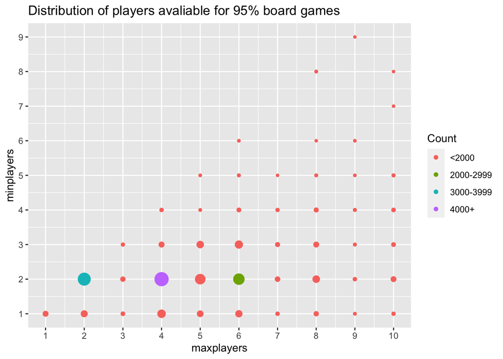

### Playing time

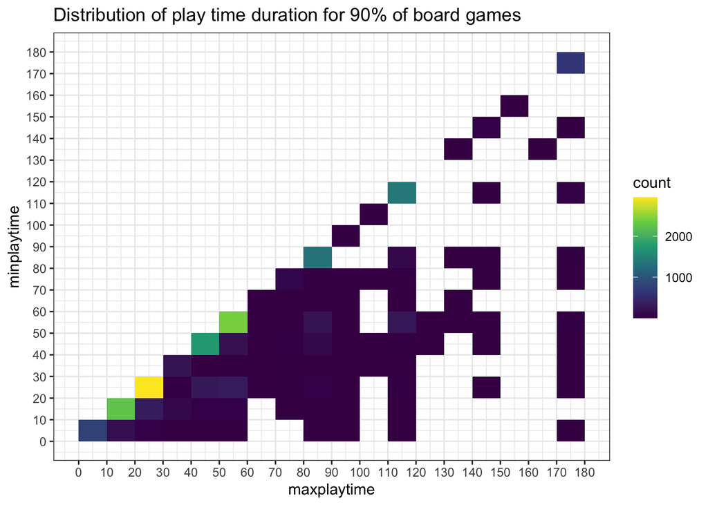

```r
# Assign new group
df <- df %>% mutate(playingtime = ifelse(maxplaytime >= 120, "Extreme",
                                         ifelse(maxplaytime >=90, "Long",
                                                ifelse(maxplaytime >=60, "Normal",
                                                       ifelse(is.na(maxplaytime),NA,"Short")))),
                    playingtime = factor(playingtime, levels =c("Short","Normal","Long","Extreme")))
```

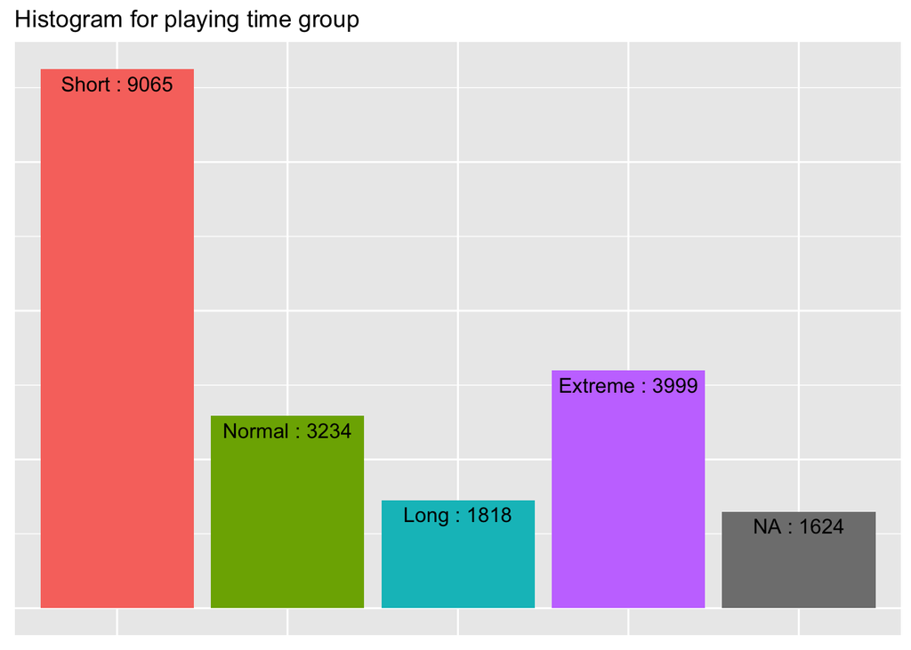